# notebook

## 1. The most Nobel of Prizes

[figure not shown]

The Nobel Prize is perhaps the worlds most well known scientific award. Except for the honor, prestige and substantial prize money the recipient also gets a gold medal showing Alfred Nobel (1833 - 1896) who established the prize. Every year it's given to scientists and scholars in the categories chemistry, literature, physics, physiology or medicine, economics, and peace. The first Nobel Prize was handed out in 1901, and at that time the Prize was very Eurocentric and male-focused, but nowadays it's not biased in any way whatsoever. Surely. Right?

Well, we're going to find out! The Nobel Foundation has made a dataset available of all prize winners from the start of the prize, in 1901, to 2016. Let's load it in and take a look.

```r
# Loading in required libraries
library(tidyverse)
# Reading in the Nobel Prize data
nobel <- read_csv("datasets/nobel.csv")

# Taking a look at the first couple of winners
head(nobel)
```

| year | category | prize | motivation | prize_share | laureate_id | laureate_type | full_name | birth_date | birth_city | birth_country | sex | organization_name | organization_city | organization_country | death_date | death_city | death_country |
| --- | --- | --- | --- | --- | --- | --- | --- | --- | --- | --- | --- | --- | --- | --- | --- | --- | --- |
| 1901 | Chemistry | The Nobel Prize in Chemistry 1901 | "in recognition of the extraordinary services he has rendered by the discovery of the laws of chemical dynamics and osmotic pressure in solutions" | 1/1 | 160 | Individual | Jacobus Henricus van 't Hoff | 1852-08-30 | Rotterdam | Netherlands | Male | Berlin University | Berlin | Germany | 1911-03-01 | Berlin | Germany |
| 1901 | Literature | The Nobel Prize in Literature 1901 | "in special recognition of his poetic composition, which gives evidence of lofty idealism, artistic perfection and a rare combination of the qualities of both heart and intellect" | 1/1 | 569 | Individual | Sully Prudhomme | 1839-03-16 | Paris | France | Male | NA | NA | NA | 1907-09-07 | Châtenay | France |
| 1901 | Medicine | The Nobel Prize in Physiology or Medicine 1901 | "for his work on serum therapy, especially its application against diphtheria, by which he has opened a new road in the domain of medical science and thereby placed in the hands of the physician a vic… | 1/1 | 293 | Individual | Emil Adolf von Behring | 1854-03-15 | Hansdorf (Lawice) | Prussia (Poland) | Male | Marburg University | Marburg | Germany | 1917-03-31 | Marburg | Germany |
| 1901 | Peace | The Nobel Peace Prize 1901 | NA | 1/2 | 462 | Individual | Jean Henry Dunant | 1828-05-08 | Geneva | Switzerland | Male | NA | NA | NA | 1910-10-30 | Heiden | Switzerland |
| 1901 | Peace | The Nobel Peace Prize 1901 | NA | 1/2 | 463 | Individual | Frédéric Passy | 1822-05-20 | Paris | France | Male | NA | NA | NA | 1912-06-12 | Paris | France |
| 1901 | Physics | The Nobel Prize in Physics 1901 | "in recognition of the extraordinary services he has rendered by the discovery of the remarkable rays subsequently named after him" | 1/1 | 1 | Individual | Wilhelm Conrad Röntgen | 1845-03-27 | Lennep (Remscheid) | Prussia (Germany) | Male | Munich University | Munich | Germany | 1923-02-10 | Munich | Germany |

```r
library(testthat)
library(IRkernel.testthat)

run_tests({
    test_that("Test that tidyverse is loaded", {
    expect_true( "package:tidyverse" %in% search(),
        info = "The tidyverse package should be loaded using library().")
    })

    test_that("Read in data correctly.", {
        expect_is(nobel, "tbl_df",
            info = 'You should use read_csv (with an underscore) to read "datasets/nobel.csv" into nobel.')
    })

    test_that("Read in data correctly.", {
        nobel_temp <- read_csv('datasets/nobel.csv')
        expect_equivalent(nobel, nobel_temp,
            info = 'nobel should contain the data in "datasets/nobel.csv".')
    })
})
```

[output not shown]

## 2. So, who gets the Nobel Prize?

Just looking at the first couple of prize winners, or Nobel laureates as they are also called, we already see a celebrity: Wilhelm Conrad Röntgen, the guy who discovered X-rays. And actually, we see that all of the winners in 1901 were guys that came from Europe. But that was back in 1901, looking at all winners in the dataset, from 1901 to 2016, which sex and which country is the most commonly represented?

```r
# Counting the number of (possibly shared) Nobel Prizes handed
# out between 1901 and 2016
nobel %>% filter(year>=1902 & year<=2016)

# Counting the number of prizes won by male and female recipients.
nobel %>%
    group_by(sex)%>%
    summarize(n())

# Counting the number of prizes won by different nationalities.
nobel %>%
    group_by(birth_country)%>%
    summarize(n())
```

| year | category | prize | motivation | prize_share | laureate_id | laureate_type | full_name | birth_date | birth_city | birth_country | sex | organization_name | organization_city | organization_country | death_date | death_city | death_country |
| --- | --- | --- | --- | --- | --- | --- | --- | --- | --- | --- | --- | --- | --- | --- | --- | --- | --- |
| 1902 | Chemistry | The Nobel Prize in Chemistry 1902 | "in recognition of the extraordinary services he has rendered by his work on sugar and purine syntheses" | 1/1 | 161 | Individual | Hermann Emil Fischer | 1852-10-09 | Euskirchen | Prussia (Germany) | Male | Berlin University | Berlin | Germany | 1919-07-15 | Berlin | Germany |
| 1902 | Literature | The Nobel Prize in Literature 1902 | "the greatest living master of the art of historical writing, with special reference to his monumental work, <I>A history of Rome</I>" | 1/1 | 571 | Individual | Christian Matthias Theodor Mommsen | 1817-11-30 | Garding | Schleswig (Germany) | Male | NA | NA | NA | 1903-11-01 | Charlottenburg | Germany |
| 1902 | Medicine | The Nobel Prize in Physiology or Medicine 1902 | "for his work on malaria, by which he has shown how it enters the organism and thereby has laid the foundation for successful research on this disease and methods of combating it" | 1/1 | 294 | Individual | Ronald Ross | 1857-05-13 | Almora | India | Male | University College | Liverpool | United Kingdom | 1932-09-16 | Putney Heath | United Kingdom |
| 1902 | Peace | The Nobel Peace Prize 1902 | NA | 1/2 | 464 | Individual | Élie Ducommun | 1833-02-19 | Geneva | Switzerland | Male | NA | NA | NA | 1906-12-07 | Bern | Switzerland |
| 1902 | Peace | The Nobel Peace Prize 1902 | NA | 1/2 | 465 | Individual | Charles Albert Gobat | 1843-05-21 | Tramelan | Switzerland | Male | NA | NA | NA | 1914-03-16 | Bern | Switzerland |
| 1902 | Physics | The Nobel Prize in Physics 1902 | "in recognition of the extraordinary service they rendered by their researches into the influence of magnetism upon radiation phenomena" | 1/2 | 2 | Individual | Hendrik Antoon Lorentz | 1853-07-18 | Arnhem | Netherlands | Male | Leiden University | Leiden | Netherlands | 1928-02-04 | NA | Netherlands |
| 1902 | Physics | The Nobel Prize in Physics 1902 | "in recognition of the extraordinary service they rendered by their researches into the influence of magnetism upon radiation phenomena" | 1/2 | 3 | Individual | Pieter Zeeman | 1865-05-25 | Zonnemaire | Netherlands | Male | Amsterdam University | Amsterdam | Netherlands | 1943-10-09 | Amsterdam | Netherlands |
| 1903 | Chemistry | The Nobel Prize in Chemistry 1903 | "in recognition of the extraordinary services he has rendered to the advancement of chemistry by his electrolytic theory of dissociation" | 1/1 | 162 | Individual | Svante August Arrhenius | 1859-02-19 | Vik | Sweden | Male | Stockholm University | Stockholm | Sweden | 1927-10-02 | Stockholm | Sweden |
| 1903 | Literature | The Nobel Prize in Literature 1903 | "as a tribute to his noble, magnificent and versatile poetry, which has always been distinguished by both the freshness of its inspiration and the rare purity of its spirit" | 1/1 | 572 | Individual | Bjørnstjerne Martinus Bjørnson | 1832-12-08 | Kvikne | Norway | Male | NA | NA | NA | 1910-04-26 | Paris | France |
| 1903 | Medicine | The Nobel Prize in Physiology or Medicine 1903 | "in recognition of his contribution to the treatment of diseases, especially lupus vulgaris, with concentrated light radiation, whereby he has opened a new avenue for medical science" | 1/1 | 295 | Individual | Niels Ryberg Finsen | 1860-12-15 | Thorshavn | Faroe Islands (Denmark) | Male | Finsen Medical Light Institute | Copenhagen | Denmark | 1904-09-24 | Copenhagen | Denmark |
| 1903 | Peace | The Nobel Peace Prize 1903 | NA | 1/1 | 466 | Individual | William Randal Cremer | 1828-03-18 | Fareham | United Kingdom | Male | NA | NA | NA | 1908-07-22 | London | United Kingdom |
| 1903 | Physics | The Nobel Prize in Physics 1903 | "in recognition of the extraordinary services he has rendered by his discovery of spontaneous radioactivity" | 1/2 | 4 | Individual | Antoine Henri Becquerel | 1852-12-15 | Paris | France | Male | École Polytechnique | Paris | France | 1908-08-25 | NA | France |
| 1903 | Physics | The Nobel Prize in Physics 1903 | "in recognition of the extraordinary services they have rendered by their joint researches on the radiation phenomena discovered by Professor Henri Becquerel" | 1/4 | 5 | Individual | Pierre Curie | 1859-05-15 | Paris | France | Male | École municipale de physique et de chimie industrielles (Municipal School of Industrial Physics and Chemistry) | Paris | France | 1906-04-19 | Paris | France |
| 1903 | Physics | The Nobel Prize in Physics 1903 | "in recognition of the extraordinary services they have rendered by their joint researches on the radiation phenomena discovered by Professor Henri Becquerel" | 1/4 | 6 | Individual | Marie Curie, née Sklodowska | 1867-11-07 | Warsaw | Russian Empire (Poland) | Female | NA | NA | NA | 1934-07-04 | Sallanches | France |
| 1904 | Chemistry | The Nobel Prize in Chemistry 1904 | "in recognition of his services in the discovery of the inert gaseous elements in air, and his determination of their place in the periodic system" | 1/1 | 163 | Individual | Sir William Ramsay | 1852-10-02 | Glasgow | Scotland | Male | University College | London | United Kingdom | 1916-07-23 | High Wycombe | United Kingdom |
| 1904 | Literature | The Nobel Prize in Literature 1904 | "in recognition of the fresh originality and true inspiration of his poetic production, which faithfully reflects the natural scenery and native spirit of his people, and, in addition, his significant… | 1/2 | 573 | Individual | Frédéric Mistral | 1830-09-08 | Maillane | France | Male | NA | NA | NA | 1914-03-25 | Maillane | France |
| 1904 | Literature | The Nobel Prize in Literature 1904 | "in recognition of the numerous and brilliant compositions which, in an individual and original manner, have revived the great traditions of the Spanish drama" | 1/2 | 574 | Individual | José Echegaray y Eizaguirre | 1832-04-19 | Madrid | Spain | Male | NA | NA | NA | 1916-09-04 | Madrid | Spain |
| 1904 | Medicine | The Nobel Prize in Physiology or Medicine 1904 | "in recognition of his work on the physiology of digestion, through which knowledge on vital aspects of the subject has been transformed and enlarged" | 1/1 | 296 | Individual | Ivan Petrovich Pavlov | 1849-09-14 | Ryazan | Russia | Male | Military Medical Academy | St. Petersburg | Russia | 1936-02-27 | Leningrad | Russia |
| 1904 | Peace | The Nobel Peace Prize 1904 | NA | 1/1 | 467 | Organization | Institut de droit international (Institute of International Law) | NA | NA | NA | NA | NA | NA | NA | NA | NA | NA |
| 1904 | Physics | The Nobel Prize in Physics 1904 | "for his investigations of the densities of the most important gases and for his discovery of argon in connection with these studies" | 1/1 | 8 | Individual | Lord Rayleigh (John William Strutt) | 1842-11-12 | Langford Grove, Maldon, Essex | United Kingdom | Male | Royal Institution of Great Britain | London | United Kingdom | 1919-06-30 | NA | United Kingdom |
| 1905 | Chemistry | The Nobel Prize in Chemistry 1905 | "in recognition of his services in the advancement of organic chemistry and the chemical industry, through his work on organic dyes and hydroaromatic compounds" | 1/1 | 164 | Individual | Johann Friedrich Wilhelm Adolf von Baeyer | 1835-10-31 | Berlin | Prussia (Germany) | Male | Munich University | Munich | Germany | 1917-08-20 | Starnberg | Germany |
| 1905 | Literature | The Nobel Prize in Literature 1905 | "because of his outstanding merits as an epic writer" | 1/1 | 575 | Individual | Henryk Sienkiewicz | 1846-05-05 | Wola Okrzejska | Poland | Male | NA | NA | NA | 1916-11-15 | Vevey | Switzerland |
| 1905 | Medicine | The Nobel Prize in Physiology or Medicine 1905 | "for his investigations and discoveries in relation to tuberculosis" | 1/1 | 297 | Individual | Robert Koch | 1843-12-11 | Clausthal (Clausthal-Zellerfeld) | Germany | Male | Institute for Infectious Diseases | Berlin | Germany | 1910-05-27 | Baden-Baden | Germany |
| 1905 | Peace | The Nobel Peace Prize 1905 | NA | 1/1 | 468 | Individual | Baroness Bertha Sophie Felicita von Suttner, née Countess Kinsky von Chinic und Tettau | 1843-06-09 | Prague | Austrian Empire (Czech Republic) | Female | NA | NA | NA | 1914-06-21 | Vienna | Austria |
| 1905 | Physics | The Nobel Prize in Physics 1905 | "for his work on cathode rays" | 1/1 | 9 | Individual | Philipp Eduard Anton von Lenard | 1862-06-07 | Pressburg (Bratislava) | Hungary (Slovakia) | Male | Kiel University | Kiel | Germany | 1947-05-20 | Messelhausen | Germany |
| 1906 | Chemistry | The Nobel Prize in Chemistry 1906 | "in recognition of the great services rendered by him in his investigation and isolation of the element fluorine, and for the adoption in the service of science of the electric furnace called after hi… | 1/1 | 165 | Individual | Henri Moissan | 1852-09-28 | Paris | France | Male | Sorbonne University | Paris | France | 1907-02-20 | Paris | France |
| 1906 | Literature | The Nobel Prize in Literature 1906 | "not only in consideration of his deep learning and critical research, but above all as a tribute to the creative energy, freshness of style, and lyrical force which characterize his poetic masterpiec… | 1/1 | 576 | Individual | Giosuè Carducci | 1835-07-27 | Val di Castello | Tuscany (Italy) | Male | NA | NA | NA | 1907-02-16 | Bologna | Italy |
| 1906 | Medicine | The Nobel Prize in Physiology or Medicine 1906 | "in recognition of their work on the structure of the nervous system" | 1/2 | 298 | Individual | Camillo Golgi | 1843-07-07 | Corteno | Italy | Male | Pavia University | Pavia | Italy | 1926-01-21 | Pavia | Italy |
| 1906 | Medicine | The Nobel Prize in Physiology or Medicine 1906 | "in recognition of their work on the structure of the nervous system" | 1/2 | 299 | Individual | Santiago Ramón y Cajal | 1852-05-01 | Petilla de Aragó | Spain | Male | Madrid University | Madrid | Spain | 1934-10-17 | Madrid | Spain |
| 1906 | Peace | The Nobel Peace Prize 1906 | NA | 1/1 | 470 | Individual | Theodore Roosevelt | 1858-10-27 | New York, NY | United States of America | Male | NA | NA | NA | 1919-01-06 | Oyster Bay, NY | United States of America |
| ... | ... | ... | ... | ... | ... | ... | ... | ... | ... | ... | ... | ... | ... | ... | ... | ... | ... |
| 2014 | Medicine | The Nobel Prize in Physiology or Medicine 2014 | "for their discoveries of cells that constitute a positioning system in the brain" | 1/2 | 903 | Individual | John O'Keefe | 1939-11-18 | New York, NY | United States of America | Male | University College | London | United Kingdom | NA | NA | NA |
| 2014 | Medicine | The Nobel Prize in Physiology or Medicine 2014 | "for their discoveries of cells that constitute a positioning system in the brain" | 1/4 | 904 | Individual | May-Britt Moser | 1963-01-04 | Fosnavåg | Norway | Female | Norwegian University of Science and Technology (NTNU) | Trondheim | Norway | NA | NA | NA |
| 2014 | Medicine | The Nobel Prize in Physiology or Medicine 2014 | "for their discoveries of cells that constitute a positioning system in the brain" | 1/4 | 905 | Individual | Edvard I. Moser | 1962-04-27 | Ålesund | Norway | Male | Norwegian University of Science and Technology (NTNU) | Trondheim | Norway | NA | NA | NA |
| 2014 | Peace | The Nobel Peace Prize 2014 | "for their struggle against the suppression of children and young people and for the right of all children to education" | 1/2 | 913 | Individual | Kailash Satyarthi | 1954-01-11 | Vidisha | India | Male | NA | NA | NA | NA | NA | NA |
| 2014 | Peace | The Nobel Peace Prize 2014 | "for their struggle against the suppression of children and young people and for the right of all children to education" | 1/2 | 914 | Individual | Malala Yousafzai | 1997-07-12 | Mingora | Pakistan | Female | NA | NA | NA | NA | NA | NA |
| 2014 | Physics | The Nobel Prize in Physics 2014 | "for the invention of efficient blue light-emitting diodes which has enabled bright and energy-saving white light sources" | 1/3 | 906 | Individual | Isamu Akasaki | 1929-01-30 | Chiran | Japan | Male | Meijo University | Nagoya | Japan | NA | NA | NA |
| 2014 | Physics | The Nobel Prize in Physics 2014 | "for the invention of efficient blue light-emitting diodes which has enabled bright and energy-saving white light sources" | 1/3 | 907 | Individual | Hiroshi Amano | 1960-09-11 | Hamamatsu | Japan | Male | Nagoya University | Nagoya | Japan | NA | NA | NA |
| 2014 | Physics | The Nobel Prize in Physics 2014 | "for the invention of efficient blue light-emitting diodes which has enabled bright and energy-saving white light sources" | 1/3 | 908 | Individual | Shuji Nakamura | 1954-05-22 | Ikata | Japan | Male | University of California | Santa Barbara, CA | United States of America | NA | NA | NA |
| 2015 | Chemistry | The Nobel Prize in Chemistry 2015 | "for mechanistic studies of DNA repair" | 1/3 | 921 | Individual | Tomas Lindahl | 1938-01-28 | Stockholm | Sweden | Male | Francis Crick Institute | Hertfordshire | United Kingdom | NA | NA | NA |
| 2015 | Chemistry | The Nobel Prize in Chemistry 2015 | "for mechanistic studies of DNA repair" | 1/3 | 922 | Individual | Paul Modrich | 1946-06-13 | Raton, NM | United States of America | Male | Howard Hughes Medical Institute | Durham, NC | United States of America | NA | NA | NA |
| 2015 | Chemistry | The Nobel Prize in Chemistry 2015 | "for mechanistic studies of DNA repair" | 1/3 | 923 | Individual | Aziz Sancar | 1946-09-08 | Savur | Turkey | Male | University of North Carolina | Chapel Hill, NC | United States of America | NA | NA | NA |
| 2015 | Economics | The Sveriges Riksbank Prize in Economic Sciences 2015 | "for his analysis of consumption, poverty, and welfare" | 1/1 | 926 | Individual | Angus Deaton | 1945-10-19 | Edinburgh | United Kingdom | Male | Princeton University | Princeton, NJ | United States of America | NA | NA | NA |
| 2015 | Literature | The Nobel Prize in Literature 2015 | "for her polyphonic writings, a monument to suffering and courage in our time" | 1/1 | 924 | Individual | Svetlana Alexievich | 1948-05-31 | Ivano-Frankivsk | Ukraine | Female | NA | NA | NA | NA | NA | NA |
| 2015 | Medicine | The Nobel Prize in Physiology or Medicine 2015 | "for their discoveries concerning a novel therapy against infections caused by roundworm parasites" | 1/4 | 916 | Individual | William C. Campbell | 1930-06-28 | Ramelton | Ireland | Male | Drew University | Madison, NJ | United States of America | NA | NA | NA |
| 2015 | Medicine | The Nobel Prize in Physiology or Medicine 2015 | "for their discoveries concerning a novel therapy against infections caused by roundworm parasites" | 1/4 | 917 | Individual | Satoshi Ōmura | 1935-07-12 | Yamanashi Prefecture | Japan | Male | Kitasato University | Tokyo | Japan | NA | NA | NA |
| 2015 | Medicine | The Nobel Prize in Physiology or Medicine 2015 | "for her discoveries concerning a novel therapy against Malaria" | 1/2 | 918 | Individual | Youyou Tu | 1930-12-30 | Zhejiang Ningbo | China | Female | China Academy of Traditional Chinese Medicine | Beijing | China | NA | NA | NA |
| 2015 | Peace | The Nobel Peace Prize 2015 | "for its decisive contribution to the building of a pluralistic democracy in Tunisia in the wake of the Jasmine Revolution of 2011" | 1/1 | 925 | Organization | National Dialogue Quartet | NA | NA | NA | NA | NA | NA | NA | NA | NA | NA |
| 2015 | Physics | The Nobel Prize in Physics 2015 | "for the discovery of neutrino oscillations, which shows that neutrinos have mass" | 1/2 | 919 | Individual | Takaaki Kajita | 1959-03-09 | Higashimatsuyama | Japan | Male | University of Tokyo | Kashiwa | Japan | NA | NA | NA |
| 2015 | Physics | The Nobel Prize in Physics 2015 | "for the discovery of neutrino oscillations, which shows that neutrinos have mass" | 1/2 | 920 | Individual | Arthur B. McDonald | 1943-08-29 | Sydney | Canada | Male | Queen's University | Kingston | Canada | NA | NA | NA |
| 2016 | Chemistry | The Nobel Prize in Chemistry 2016 | "for the design and synthesis of molecular machines" | 1/3 | 931 | Individual | Jean-Pierre Sauvage | 1944-10-21 | Paris | France | Male | University of Strasbourg | Strasbourg | France | NA | NA | NA |
| 2016 | Chemistry | The Nobel Prize in Chemistry 2016 | "for the design and synthesis of molecular machines" | 1/3 | 932 | Individual | Sir J. Fraser Stoddart | 1942-05-24 | Edinburgh | United Kingdom | Male | Northwestern University | Evanston, IL | United States of America | NA | NA | NA |
| 2016 | Chemistry | The Nobel Prize in Chemistry 2016 | "for the design and synthesis of molecular machines" | 1/3 | 933 | Individual | Bernard L. Feringa | 1951-05-18 | Barger-Compascuum | Netherlands | Male | University of Groningen | Groningen | Netherlands | NA | NA | NA |
| 2016 | Economics | The Sveriges Riksbank Prize in Economic Sciences 2016 | "for their contributions to contract theory" | 1/2 | 935 | Individual | Oliver Hart | 1948-10-09 | London | United Kingdom | Male | Harvard University | Cambridge, MA | United States of America | NA | NA | NA |
| 2016 | Economics | The Sveriges Riksbank Prize in Economic Sciences 2016 | "for their contributions to contract theory" | 1/2 | 936 | Individual | Bengt Holmström | 1949-04-18 | Helsinki | Finland | Male | Massachusetts Institute of Technology (MIT) | Cambridge, MA | United States of America | NA | NA | NA |
| 2016 | Literature | The Nobel Prize in Literature 2016 | "for having created new poetic expressions within the great American song tradition" | 1/1 | 937 | Individual | Bob Dylan | 1941-05-24 | Duluth, MN | United States of America | Male | NA | NA | NA | NA | NA | NA |
| 2016 | Medicine | The Nobel Prize in Physiology or Medicine 2016 | "for his discoveries of mechanisms for autophagy" | 1/1 | 927 | Individual | Yoshinori Ohsumi | 1945-02-09 | Fukuoka | Japan | Male | Tokyo Institute of Technology | Tokyo | Japan | NA | NA | NA |
| 2016 | Peace | The Nobel Peace Prize 2016 | "for his resolute efforts to bring the country's more than 50-year-long civil war to an end" | 1/1 | 934 | Individual | Juan Manuel Santos | 1951-08-10 | Bogotá | Colombia | Male | NA | NA | NA | NA | NA | NA |
| 2016 | Physics | The Nobel Prize in Physics 2016 | "for theoretical discoveries of topological phase transitions and topological phases of matter" | 1/2 | 928 | Individual | David J. Thouless | 1934-09-21 | Bearsden | United Kingdom | Male | University of Washington | Seattle, WA | United States of America | NA | NA | NA |
| 2016 | Physics | The Nobel Prize in Physics 2016 | "for theoretical discoveries of topological phase transitions and topological phases of matter" | 1/4 | 929 | Individual | F. Duncan M. Haldane | 1951-09-14 | London | United Kingdom | Male | Princeton University | Princeton, NJ | United States of America | NA | NA | NA |
| 2016 | Physics | The Nobel Prize in Physics 2016 | "for theoretical discoveries of topological phase transitions and topological phases of matter" | 1/4 | 930 | Individual | J. Michael Kosterlitz | 1943-06-22 | Aberdeen | United Kingdom | Male | Brown University | Providence, RI | United States of America | NA | NA | NA |

| sex | n() |
| --- | --- |
| Female | 49 |
| Male | 836 |
| NA | 26 |

| birth_country | n() |
| --- | --- |
| Argentina | 4 |
| Australia | 10 |
| Austria | 14 |
| Austria-Hungary (Austria) | 1 |
| Austria-Hungary (Bosnia and Herzegovina) | 1 |
| Austria-Hungary (Croatia) | 1 |
| Austria-Hungary (Czech Republic) | 4 |
| Austria-Hungary (Hungary) | 3 |
| Austria-Hungary (Poland) | 1 |
| Austria-Hungary (Slovenia) | 1 |
| Austria-Hungary (Ukraine) | 1 |
| Austrian Empire (Austria) | 2 |
| Austrian Empire (Czech Republic) | 1 |
| Austrian Empire (Italy) | 1 |
| Bavaria (Germany) | 1 |
| Belgium | 9 |
| Bosnia (Bosnia and Herzegovina) | 1 |
| Brazil | 1 |
| British India (Bangladesh) | 1 |
| British India (India) | 1 |
| British Mandate of Palestine (Israel) | 5 |
| British Protectorate of Palestine (Israel) | 1 |
| British West Indies (Saint Lucia) | 1 |
| Bulgaria | 1 |
| Burma (Myanmar) | 1 |
| Canada | 18 |
| Chile | 2 |
| China | 11 |
| Colombia | 2 |
| Costa Rica | 1 |
| ... | ... |
| Russian Empire (Finland) | 3 |
| Russian Empire (Latvia) | 1 |
| Russian Empire (Lithuania) | 1 |
| Russian Empire (Poland) | 5 |
| Russian Empire (Russia) | 2 |
| Russian Empire (Ukraine) | 2 |
| Saint Lucia | 1 |
| Schleswig (Germany) | 2 |
| Scotland | 9 |
| South Africa | 9 |
| Southern Rhodesia (Zimbabwe) | 1 |
| Spain | 7 |
| Sweden | 29 |
| Switzerland | 16 |
| Taiwan | 1 |
| Tibet (People's Republic of China) | 1 |
| Trinidad | 1 |
| Turkey | 2 |
| Tuscany (Italy) | 1 |
| Ukraine | 1 |
| Union of Soviet Socialist Republics (Belarus) | 1 |
| Union of Soviet Socialist Republics (Russia) | 4 |
| United Kingdom | 85 |
| United States of America | 259 |
| Venezuela | 1 |
| Vietnam | 1 |
| W&uuml;rttemberg (Germany) | 1 |
| West Germany (Germany) | 5 |
| Yemen | 1 |
| NA | 26 |

```r
last_value <- .Last.value

correct_value <- nobel %>%
    group_by(birth_country) %>%
    count()  %>%
    arrange(desc(n))  %>%
    head(20)

run_tests({
    test_that("That the by country count is correct", {
    expect_equivalent(last_value$birth_country[1], last_value$birth_country[1],
        info = "The countries should be arranged by n, arrange(desc(n)), and the top country should be United States of America")
    })
})
```

[output not shown]

## 3. USA dominance

Not so surprising perhaps: the most common Nobel laureate between 1901 and 2016 was a man born in the United States of America. But in 1901 all the laureates were European. When did the USA start to dominate the Nobel Prize charts?

```r
nobel %>%
    mutate(
        usa_born_winner =
            ifelse(birth_country=="United States of America",
               TRUE, FALSE),
        decade=floor(year / 10) * 10)
```

| year | category | prize | motivation | prize_share | laureate_id | laureate_type | full_name | birth_date | birth_city | birth_country | sex | organization_name | organization_city | organization_country | death_date | death_city | death_country | usa_born_winner | decade |
| --- | --- | --- | --- | --- | --- | --- | --- | --- | --- | --- | --- | --- | --- | --- | --- | --- | --- | --- | --- |
| 1901 | Chemistry | The Nobel Prize in Chemistry 1901 | "in recognition of the extraordinary services he has rendered by the discovery of the laws of chemical dynamics and osmotic pressure in solutions" | 1/1 | 160 | Individual | Jacobus Henricus van 't Hoff | 1852-08-30 | Rotterdam | Netherlands | Male | Berlin University | Berlin | Germany | 1911-03-01 | Berlin | Germany | FALSE | 1900 |
| 1901 | Literature | The Nobel Prize in Literature 1901 | "in special recognition of his poetic composition, which gives evidence of lofty idealism, artistic perfection and a rare combination of the qualities of both heart and intellect" | 1/1 | 569 | Individual | Sully Prudhomme | 1839-03-16 | Paris | France | Male | NA | NA | NA | 1907-09-07 | Châtenay | France | FALSE | 1900 |
| 1901 | Medicine | The Nobel Prize in Physiology or Medicine 1901 | "for his work on serum therapy, especially its application against diphtheria, by which he has opened a new road in the domain of medical science and thereby placed in the hands of the physician a vic… | 1/1 | 293 | Individual | Emil Adolf von Behring | 1854-03-15 | Hansdorf (Lawice) | Prussia (Poland) | Male | Marburg University | Marburg | Germany | 1917-03-31 | Marburg | Germany | FALSE | 1900 |
| 1901 | Peace | The Nobel Peace Prize 1901 | NA | 1/2 | 462 | Individual | Jean Henry Dunant | 1828-05-08 | Geneva | Switzerland | Male | NA | NA | NA | 1910-10-30 | Heiden | Switzerland | FALSE | 1900 |
| 1901 | Peace | The Nobel Peace Prize 1901 | NA | 1/2 | 463 | Individual | Frédéric Passy | 1822-05-20 | Paris | France | Male | NA | NA | NA | 1912-06-12 | Paris | France | FALSE | 1900 |
| 1901 | Physics | The Nobel Prize in Physics 1901 | "in recognition of the extraordinary services he has rendered by the discovery of the remarkable rays subsequently named after him" | 1/1 | 1 | Individual | Wilhelm Conrad Röntgen | 1845-03-27 | Lennep (Remscheid) | Prussia (Germany) | Male | Munich University | Munich | Germany | 1923-02-10 | Munich | Germany | FALSE | 1900 |
| 1902 | Chemistry | The Nobel Prize in Chemistry 1902 | "in recognition of the extraordinary services he has rendered by his work on sugar and purine syntheses" | 1/1 | 161 | Individual | Hermann Emil Fischer | 1852-10-09 | Euskirchen | Prussia (Germany) | Male | Berlin University | Berlin | Germany | 1919-07-15 | Berlin | Germany | FALSE | 1900 |
| 1902 | Literature | The Nobel Prize in Literature 1902 | "the greatest living master of the art of historical writing, with special reference to his monumental work, <I>A history of Rome</I>" | 1/1 | 571 | Individual | Christian Matthias Theodor Mommsen | 1817-11-30 | Garding | Schleswig (Germany) | Male | NA | NA | NA | 1903-11-01 | Charlottenburg | Germany | FALSE | 1900 |
| 1902 | Medicine | The Nobel Prize in Physiology or Medicine 1902 | "for his work on malaria, by which he has shown how it enters the organism and thereby has laid the foundation for successful research on this disease and methods of combating it" | 1/1 | 294 | Individual | Ronald Ross | 1857-05-13 | Almora | India | Male | University College | Liverpool | United Kingdom | 1932-09-16 | Putney Heath | United Kingdom | FALSE | 1900 |
| 1902 | Peace | The Nobel Peace Prize 1902 | NA | 1/2 | 464 | Individual | Élie Ducommun | 1833-02-19 | Geneva | Switzerland | Male | NA | NA | NA | 1906-12-07 | Bern | Switzerland | FALSE | 1900 |
| 1902 | Peace | The Nobel Peace Prize 1902 | NA | 1/2 | 465 | Individual | Charles Albert Gobat | 1843-05-21 | Tramelan | Switzerland | Male | NA | NA | NA | 1914-03-16 | Bern | Switzerland | FALSE | 1900 |
| 1902 | Physics | The Nobel Prize in Physics 1902 | "in recognition of the extraordinary service they rendered by their researches into the influence of magnetism upon radiation phenomena" | 1/2 | 2 | Individual | Hendrik Antoon Lorentz | 1853-07-18 | Arnhem | Netherlands | Male | Leiden University | Leiden | Netherlands | 1928-02-04 | NA | Netherlands | FALSE | 1900 |
| 1902 | Physics | The Nobel Prize in Physics 1902 | "in recognition of the extraordinary service they rendered by their researches into the influence of magnetism upon radiation phenomena" | 1/2 | 3 | Individual | Pieter Zeeman | 1865-05-25 | Zonnemaire | Netherlands | Male | Amsterdam University | Amsterdam | Netherlands | 1943-10-09 | Amsterdam | Netherlands | FALSE | 1900 |
| 1903 | Chemistry | The Nobel Prize in Chemistry 1903 | "in recognition of the extraordinary services he has rendered to the advancement of chemistry by his electrolytic theory of dissociation" | 1/1 | 162 | Individual | Svante August Arrhenius | 1859-02-19 | Vik | Sweden | Male | Stockholm University | Stockholm | Sweden | 1927-10-02 | Stockholm | Sweden | FALSE | 1900 |
| 1903 | Literature | The Nobel Prize in Literature 1903 | "as a tribute to his noble, magnificent and versatile poetry, which has always been distinguished by both the freshness of its inspiration and the rare purity of its spirit" | 1/1 | 572 | Individual | Bjørnstjerne Martinus Bjørnson | 1832-12-08 | Kvikne | Norway | Male | NA | NA | NA | 1910-04-26 | Paris | France | FALSE | 1900 |
| 1903 | Medicine | The Nobel Prize in Physiology or Medicine 1903 | "in recognition of his contribution to the treatment of diseases, especially lupus vulgaris, with concentrated light radiation, whereby he has opened a new avenue for medical science" | 1/1 | 295 | Individual | Niels Ryberg Finsen | 1860-12-15 | Thorshavn | Faroe Islands (Denmark) | Male | Finsen Medical Light Institute | Copenhagen | Denmark | 1904-09-24 | Copenhagen | Denmark | FALSE | 1900 |
| 1903 | Peace | The Nobel Peace Prize 1903 | NA | 1/1 | 466 | Individual | William Randal Cremer | 1828-03-18 | Fareham | United Kingdom | Male | NA | NA | NA | 1908-07-22 | London | United Kingdom | FALSE | 1900 |
| 1903 | Physics | The Nobel Prize in Physics 1903 | "in recognition of the extraordinary services he has rendered by his discovery of spontaneous radioactivity" | 1/2 | 4 | Individual | Antoine Henri Becquerel | 1852-12-15 | Paris | France | Male | École Polytechnique | Paris | France | 1908-08-25 | NA | France | FALSE | 1900 |
| 1903 | Physics | The Nobel Prize in Physics 1903 | "in recognition of the extraordinary services they have rendered by their joint researches on the radiation phenomena discovered by Professor Henri Becquerel" | 1/4 | 5 | Individual | Pierre Curie | 1859-05-15 | Paris | France | Male | École municipale de physique et de chimie industrielles (Municipal School of Industrial Physics and Chemistry) | Paris | France | 1906-04-19 | Paris | France | FALSE | 1900 |
| 1903 | Physics | The Nobel Prize in Physics 1903 | "in recognition of the extraordinary services they have rendered by their joint researches on the radiation phenomena discovered by Professor Henri Becquerel" | 1/4 | 6 | Individual | Marie Curie, née Sklodowska | 1867-11-07 | Warsaw | Russian Empire (Poland) | Female | NA | NA | NA | 1934-07-04 | Sallanches | France | FALSE | 1900 |
| 1904 | Chemistry | The Nobel Prize in Chemistry 1904 | "in recognition of his services in the discovery of the inert gaseous elements in air, and his determination of their place in the periodic system" | 1/1 | 163 | Individual | Sir William Ramsay | 1852-10-02 | Glasgow | Scotland | Male | University College | London | United Kingdom | 1916-07-23 | High Wycombe | United Kingdom | FALSE | 1900 |
| 1904 | Literature | The Nobel Prize in Literature 1904 | "in recognition of the fresh originality and true inspiration of his poetic production, which faithfully reflects the natural scenery and native spirit of his people, and, in addition, his significant… | 1/2 | 573 | Individual | Frédéric Mistral | 1830-09-08 | Maillane | France | Male | NA | NA | NA | 1914-03-25 | Maillane | France | FALSE | 1900 |
| 1904 | Literature | The Nobel Prize in Literature 1904 | "in recognition of the numerous and brilliant compositions which, in an individual and original manner, have revived the great traditions of the Spanish drama" | 1/2 | 574 | Individual | José Echegaray y Eizaguirre | 1832-04-19 | Madrid | Spain | Male | NA | NA | NA | 1916-09-04 | Madrid | Spain | FALSE | 1900 |
| 1904 | Medicine | The Nobel Prize in Physiology or Medicine 1904 | "in recognition of his work on the physiology of digestion, through which knowledge on vital aspects of the subject has been transformed and enlarged" | 1/1 | 296 | Individual | Ivan Petrovich Pavlov | 1849-09-14 | Ryazan | Russia | Male | Military Medical Academy | St. Petersburg | Russia | 1936-02-27 | Leningrad | Russia | FALSE | 1900 |
| 1904 | Peace | The Nobel Peace Prize 1904 | NA | 1/1 | 467 | Organization | Institut de droit international (Institute of International Law) | NA | NA | NA | NA | NA | NA | NA | NA | NA | NA | NA | 1900 |
| 1904 | Physics | The Nobel Prize in Physics 1904 | "for his investigations of the densities of the most important gases and for his discovery of argon in connection with these studies" | 1/1 | 8 | Individual | Lord Rayleigh (John William Strutt) | 1842-11-12 | Langford Grove, Maldon, Essex | United Kingdom | Male | Royal Institution of Great Britain | London | United Kingdom | 1919-06-30 | NA | United Kingdom | FALSE | 1900 |
| 1905 | Chemistry | The Nobel Prize in Chemistry 1905 | "in recognition of his services in the advancement of organic chemistry and the chemical industry, through his work on organic dyes and hydroaromatic compounds" | 1/1 | 164 | Individual | Johann Friedrich Wilhelm Adolf von Baeyer | 1835-10-31 | Berlin | Prussia (Germany) | Male | Munich University | Munich | Germany | 1917-08-20 | Starnberg | Germany | FALSE | 1900 |
| 1905 | Literature | The Nobel Prize in Literature 1905 | "because of his outstanding merits as an epic writer" | 1/1 | 575 | Individual | Henryk Sienkiewicz | 1846-05-05 | Wola Okrzejska | Poland | Male | NA | NA | NA | 1916-11-15 | Vevey | Switzerland | FALSE | 1900 |
| 1905 | Medicine | The Nobel Prize in Physiology or Medicine 1905 | "for his investigations and discoveries in relation to tuberculosis" | 1/1 | 297 | Individual | Robert Koch | 1843-12-11 | Clausthal (Clausthal-Zellerfeld) | Germany | Male | Institute for Infectious Diseases | Berlin | Germany | 1910-05-27 | Baden-Baden | Germany | FALSE | 1900 |
| 1905 | Peace | The Nobel Peace Prize 1905 | NA | 1/1 | 468 | Individual | Baroness Bertha Sophie Felicita von Suttner, née Countess Kinsky von Chinic und Tettau | 1843-06-09 | Prague | Austrian Empire (Czech Republic) | Female | NA | NA | NA | 1914-06-21 | Vienna | Austria | FALSE | 1900 |
| ... | ... | ... | ... | ... | ... | ... | ... | ... | ... | ... | ... | ... | ... | ... | ... | ... | ... | ... | ... |
| 2014 | Medicine | The Nobel Prize in Physiology or Medicine 2014 | "for their discoveries of cells that constitute a positioning system in the brain" | 1/2 | 903 | Individual | John O'Keefe | 1939-11-18 | New York, NY | United States of America | Male | University College | London | United Kingdom | NA | NA | NA | TRUE | 2010 |
| 2014 | Medicine | The Nobel Prize in Physiology or Medicine 2014 | "for their discoveries of cells that constitute a positioning system in the brain" | 1/4 | 904 | Individual | May-Britt Moser | 1963-01-04 | Fosnavåg | Norway | Female | Norwegian University of Science and Technology (NTNU) | Trondheim | Norway | NA | NA | NA | FALSE | 2010 |
| 2014 | Medicine | The Nobel Prize in Physiology or Medicine 2014 | "for their discoveries of cells that constitute a positioning system in the brain" | 1/4 | 905 | Individual | Edvard I. Moser | 1962-04-27 | Ålesund | Norway | Male | Norwegian University of Science and Technology (NTNU) | Trondheim | Norway | NA | NA | NA | FALSE | 2010 |
| 2014 | Peace | The Nobel Peace Prize 2014 | "for their struggle against the suppression of children and young people and for the right of all children to education" | 1/2 | 913 | Individual | Kailash Satyarthi | 1954-01-11 | Vidisha | India | Male | NA | NA | NA | NA | NA | NA | FALSE | 2010 |
| 2014 | Peace | The Nobel Peace Prize 2014 | "for their struggle against the suppression of children and young people and for the right of all children to education" | 1/2 | 914 | Individual | Malala Yousafzai | 1997-07-12 | Mingora | Pakistan | Female | NA | NA | NA | NA | NA | NA | FALSE | 2010 |
| 2014 | Physics | The Nobel Prize in Physics 2014 | "for the invention of efficient blue light-emitting diodes which has enabled bright and energy-saving white light sources" | 1/3 | 906 | Individual | Isamu Akasaki | 1929-01-30 | Chiran | Japan | Male | Meijo University | Nagoya | Japan | NA | NA | NA | FALSE | 2010 |
| 2014 | Physics | The Nobel Prize in Physics 2014 | "for the invention of efficient blue light-emitting diodes which has enabled bright and energy-saving white light sources" | 1/3 | 907 | Individual | Hiroshi Amano | 1960-09-11 | Hamamatsu | Japan | Male | Nagoya University | Nagoya | Japan | NA | NA | NA | FALSE | 2010 |
| 2014 | Physics | The Nobel Prize in Physics 2014 | "for the invention of efficient blue light-emitting diodes which has enabled bright and energy-saving white light sources" | 1/3 | 908 | Individual | Shuji Nakamura | 1954-05-22 | Ikata | Japan | Male | University of California | Santa Barbara, CA | United States of America | NA | NA | NA | FALSE | 2010 |
| 2015 | Chemistry | The Nobel Prize in Chemistry 2015 | "for mechanistic studies of DNA repair" | 1/3 | 921 | Individual | Tomas Lindahl | 1938-01-28 | Stockholm | Sweden | Male | Francis Crick Institute | Hertfordshire | United Kingdom | NA | NA | NA | FALSE | 2010 |
| 2015 | Chemistry | The Nobel Prize in Chemistry 2015 | "for mechanistic studies of DNA repair" | 1/3 | 922 | Individual | Paul Modrich | 1946-06-13 | Raton, NM | United States of America | Male | Howard Hughes Medical Institute | Durham, NC | United States of America | NA | NA | NA | TRUE | 2010 |
| 2015 | Chemistry | The Nobel Prize in Chemistry 2015 | "for mechanistic studies of DNA repair" | 1/3 | 923 | Individual | Aziz Sancar | 1946-09-08 | Savur | Turkey | Male | University of North Carolina | Chapel Hill, NC | United States of America | NA | NA | NA | FALSE | 2010 |
| 2015 | Economics | The Sveriges Riksbank Prize in Economic Sciences 2015 | "for his analysis of consumption, poverty, and welfare" | 1/1 | 926 | Individual | Angus Deaton | 1945-10-19 | Edinburgh | United Kingdom | Male | Princeton University | Princeton, NJ | United States of America | NA | NA | NA | FALSE | 2010 |
| 2015 | Literature | The Nobel Prize in Literature 2015 | "for her polyphonic writings, a monument to suffering and courage in our time" | 1/1 | 924 | Individual | Svetlana Alexievich | 1948-05-31 | Ivano-Frankivsk | Ukraine | Female | NA | NA | NA | NA | NA | NA | FALSE | 2010 |
| 2015 | Medicine | The Nobel Prize in Physiology or Medicine 2015 | "for their discoveries concerning a novel therapy against infections caused by roundworm parasites" | 1/4 | 916 | Individual | William C. Campbell | 1930-06-28 | Ramelton | Ireland | Male | Drew University | Madison, NJ | United States of America | NA | NA | NA | FALSE | 2010 |
| 2015 | Medicine | The Nobel Prize in Physiology or Medicine 2015 | "for their discoveries concerning a novel therapy against infections caused by roundworm parasites" | 1/4 | 917 | Individual | Satoshi Ōmura | 1935-07-12 | Yamanashi Prefecture | Japan | Male | Kitasato University | Tokyo | Japan | NA | NA | NA | FALSE | 2010 |
| 2015 | Medicine | The Nobel Prize in Physiology or Medicine 2015 | "for her discoveries concerning a novel therapy against Malaria" | 1/2 | 918 | Individual | Youyou Tu | 1930-12-30 | Zhejiang Ningbo | China | Female | China Academy of Traditional Chinese Medicine | Beijing | China | NA | NA | NA | FALSE | 2010 |
| 2015 | Peace | The Nobel Peace Prize 2015 | "for its decisive contribution to the building of a pluralistic democracy in Tunisia in the wake of the Jasmine Revolution of 2011" | 1/1 | 925 | Organization | National Dialogue Quartet | NA | NA | NA | NA | NA | NA | NA | NA | NA | NA | NA | 2010 |
| 2015 | Physics | The Nobel Prize in Physics 2015 | "for the discovery of neutrino oscillations, which shows that neutrinos have mass" | 1/2 | 919 | Individual | Takaaki Kajita | 1959-03-09 | Higashimatsuyama | Japan | Male | University of Tokyo | Kashiwa | Japan | NA | NA | NA | FALSE | 2010 |
| 2015 | Physics | The Nobel Prize in Physics 2015 | "for the discovery of neutrino oscillations, which shows that neutrinos have mass" | 1/2 | 920 | Individual | Arthur B. McDonald | 1943-08-29 | Sydney | Canada | Male | Queen's University | Kingston | Canada | NA | NA | NA | FALSE | 2010 |
| 2016 | Chemistry | The Nobel Prize in Chemistry 2016 | "for the design and synthesis of molecular machines" | 1/3 | 931 | Individual | Jean-Pierre Sauvage | 1944-10-21 | Paris | France | Male | University of Strasbourg | Strasbourg | France | NA | NA | NA | FALSE | 2010 |
| 2016 | Chemistry | The Nobel Prize in Chemistry 2016 | "for the design and synthesis of molecular machines" | 1/3 | 932 | Individual | Sir J. Fraser Stoddart | 1942-05-24 | Edinburgh | United Kingdom | Male | Northwestern University | Evanston, IL | United States of America | NA | NA | NA | FALSE | 2010 |
| 2016 | Chemistry | The Nobel Prize in Chemistry 2016 | "for the design and synthesis of molecular machines" | 1/3 | 933 | Individual | Bernard L. Feringa | 1951-05-18 | Barger-Compascuum | Netherlands | Male | University of Groningen | Groningen | Netherlands | NA | NA | NA | FALSE | 2010 |
| 2016 | Economics | The Sveriges Riksbank Prize in Economic Sciences 2016 | "for their contributions to contract theory" | 1/2 | 935 | Individual | Oliver Hart | 1948-10-09 | London | United Kingdom | Male | Harvard University | Cambridge, MA | United States of America | NA | NA | NA | FALSE | 2010 |
| 2016 | Economics | The Sveriges Riksbank Prize in Economic Sciences 2016 | "for their contributions to contract theory" | 1/2 | 936 | Individual | Bengt Holmström | 1949-04-18 | Helsinki | Finland | Male | Massachusetts Institute of Technology (MIT) | Cambridge, MA | United States of America | NA | NA | NA | FALSE | 2010 |
| 2016 | Literature | The Nobel Prize in Literature 2016 | "for having created new poetic expressions within the great American song tradition" | 1/1 | 937 | Individual | Bob Dylan | 1941-05-24 | Duluth, MN | United States of America | Male | NA | NA | NA | NA | NA | NA | TRUE | 2010 |
| 2016 | Medicine | The Nobel Prize in Physiology or Medicine 2016 | "for his discoveries of mechanisms for autophagy" | 1/1 | 927 | Individual | Yoshinori Ohsumi | 1945-02-09 | Fukuoka | Japan | Male | Tokyo Institute of Technology | Tokyo | Japan | NA | NA | NA | FALSE | 2010 |
| 2016 | Peace | The Nobel Peace Prize 2016 | "for his resolute efforts to bring the country's more than 50-year-long civil war to an end" | 1/1 | 934 | Individual | Juan Manuel Santos | 1951-08-10 | Bogotá | Colombia | Male | NA | NA | NA | NA | NA | NA | FALSE | 2010 |
| 2016 | Physics | The Nobel Prize in Physics 2016 | "for theoretical discoveries of topological phase transitions and topological phases of matter" | 1/2 | 928 | Individual | David J. Thouless | 1934-09-21 | Bearsden | United Kingdom | Male | University of Washington | Seattle, WA | United States of America | NA | NA | NA | FALSE | 2010 |
| 2016 | Physics | The Nobel Prize in Physics 2016 | "for theoretical discoveries of topological phase transitions and topological phases of matter" | 1/4 | 929 | Individual | F. Duncan M. Haldane | 1951-09-14 | London | United Kingdom | Male | Princeton University | Princeton, NJ | United States of America | NA | NA | NA | FALSE | 2010 |
| 2016 | Physics | The Nobel Prize in Physics 2016 | "for theoretical discoveries of topological phase transitions and topological phases of matter" | 1/4 | 930 | Individual | J. Michael Kosterlitz | 1943-06-22 | Aberdeen | United Kingdom | Male | Brown University | Providence, RI | United States of America | NA | NA | NA | FALSE | 2010 |

```r
# Calculating the proportion of USA born winners per decade
prop_usa_winners <- nobel %>%
    mutate(
        usa_born_winner =
            ifelse(birth_country=="United States of America",
               TRUE, FALSE),
        decade=floor(year / 10) * 10)%>%
    group_by(decade)%>%
    summarize(proportion=mean(usa_born_winner,na.rm=TRUE))
# Display the proportions of USA born winners per decade
prop_usa_winners
```

| decade | proportion |
| --- | --- |
| 1900 | 0.01785714 |
| 1910 | 0.07894737 |
| 1920 | 0.07407407 |
| 1930 | 0.25454545 |
| 1940 | 0.32500000 |
| 1950 | 0.29577465 |
| 1960 | 0.28000000 |
| 1970 | 0.32038835 |
| 1980 | 0.32978723 |
| 1990 | 0.41584158 |
| 2000 | 0.43697479 |
| 2010 | 0.30379747 |

```r
correct_prop_usa_winners <- nobel %>%
    mutate(usa_born_winner = birth_country == "United States of America",
           decade = floor(year / 10) * 10 ) %>%
    group_by(decade) %>%
    summarize(proportion = mean(usa_born_winner, na.rm = TRUE))

run_tests({
    test_that("prop_usa_winners is calculated correctly", {
    expect_true("proportion" %in% names(prop_usa_winners) &
                all(prop_usa_winners$proportion %in% correct_prop_usa_winners$proportion),
        info = "The column proportion in prop_usa_winners should contain the proportion of usa_born_winner by decade.")
    })
})
```

[output not shown]

## 4. USA dominance, visualized

A table is OK, but to *see* when the USA started to dominate the Nobel charts we need a plot!

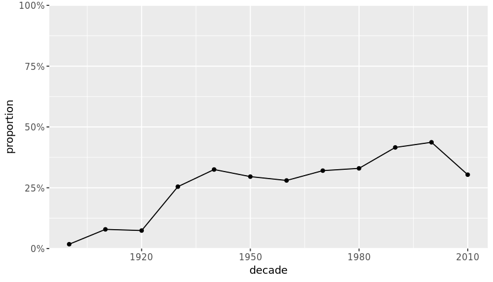

```r
# Setting the size of plots in this notebook
options(repr.plot.width=7, repr.plot.height=4)

# Plotting USA born winners
ggplot(prop_usa_winners, aes(decade, proportion))+
      geom_line()+
        geom_point()+
       scale_y_continuous(limits=c(0,1),
                          labels = scales::percent,
                         expand=c(0,0))
```

```r
p <- last_plot()

correct_p <- ggplot(prop_usa_winners, aes(decade, proportion)) +
    geom_line() + geom_point() +
    scale_y_continuous(labels = scales::percent, limits = 0:1, expand = c(0,0))

run_tests({
    test_that("The plot uses the correct dataset", {
    expect_equivalent(p$data, correct_p$data,
        info = "The plot should show the data in prop_usa_winners.")
    })

    test_that("correct columns are plotted", {
        mappings <- str_replace(as.character(p$mapping), "~", "")
        expect_true(all(c("decade", "proportion") %in% mappings),
            info = "You should plot decade on the x-axis, prop_female on the y-axis, and category should be mapped to color.")
    })
})
```

[output not shown]

## 5. What is the gender of a typical Nobel Prize winner?

So the USA became the dominating winner of the Nobel Prize first in the 1930s and has kept the leading position ever since. But one group that was in the lead from the start, and never seems to let go, are *men*. Maybe it shouldn't come as a shock that there is some imbalance between how many male and female prize winners there are, but how significant is this imbalance? And is it better or worse within specific prize categories like physics, medicine, literature, etc.?

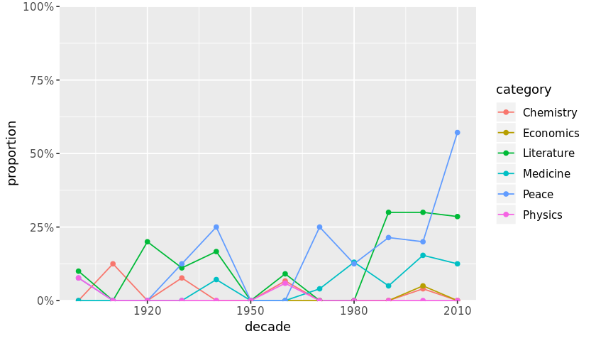

```r
# Calculating the proportion of female laureates per decade
prop_female_winners <- nobel %>%
    mutate(female_winner=ifelse(sex=="Female", TRUE, FALSE) ,
          decade=floor(year/10)*10)%>%
    group_by(decade,category)%>%
    summarize(proportion= mean(female_winner,na.rm=TRUE))


# Plotting the proportion of female laureates per decade
# Setting the size of plots in this notebook
options(repr.plot.width=7, repr.plot.height=4)

# Plotting USA born winners
ggplot(prop_female_winners, aes(decade, proportion, color=category))+
      geom_line()+
        geom_point()+
       scale_y_continuous(limits=c(0,1),
                          labels = scales::percent,
                         expand=c(0,0))
```

```r
p <- last_plot()

correct_prop_female_winners <- nobel %>%
    mutate(female_winner = sex == "Female",
           decade = floor(year / 10) * 10)  %>%
    group_by(decade, category)  %>%
    summarize(proportion = mean(female_winner, na.rm = TRUE))

run_tests({
    test_that("prop_female_winners$prop_female is correct", {
    expect_true(all(prop_female_winners$proportion %in% correct_prop_female_winners$proportion),
        info = "prop_female_winners$prop_female need to have the proportion of female winners per decade.")
    })

    test_that("correct columns are plotted", {
    mappings <- str_replace(as.character(p$mapping), "~", "")
    expect_true(all(c("decade", "proportion", "category") %in% mappings),
        info = "You should plot decade on the x-axis, prop_female on the y-axis, and category should be mapped to color.")
    })
})
```

[output not shown]

## 6. The first woman to win the Nobel Prize

The plot above is a bit messy as the lines are overplotting. But it does show some interesting trends and patterns. Overall the imbalance is pretty large with physics, economics, and chemistry having the largest imbalance. Medicine has a somewhat positive trend, and since the 1990s the literature prize is also now more balanced. The big outlier is the peace prize during the 2010s, but keep in mind that this just covers the years 2010 to 2016.

Given this imbalance, who was the first woman to receive a Nobel Prize? And in what category?

```r
# Picking out the first woman to win a Nobel Prize
nobel %>%
    filter(sex=="Female")%>%
    top_n(1, -year)
```

| year | category | prize | motivation | prize_share | laureate_id | laureate_type | full_name | birth_date | birth_city | birth_country | sex | organization_name | organization_city | organization_country | death_date | death_city | death_country |
| --- | --- | --- | --- | --- | --- | --- | --- | --- | --- | --- | --- | --- | --- | --- | --- | --- | --- |
| 1903 | Physics | The Nobel Prize in Physics 1903 | "in recognition of the extraordinary services they have rendered by their joint researches on the radiation phenomena discovered by Professor Henri Becquerel" | 1/4 | 6 | Individual | Marie Curie, née Sklodowska | 1867-11-07 | Warsaw | Russian Empire (Poland) | Female | NA | NA | NA | 1934-07-04 | Sallanches | France |

```r
last_value <- .Last.value

correct_last_value <- nobel %>%
    filter(sex == "Female")  %>%
    top_n(1, desc(year))

run_tests({
    test_that("Marie Curie is picked out.", {
    expect_equivalent(last_value$full_name, correct_last_value$full_name,
        info = "You should pick out the first woman to win a Nobel Prize. Hint: Her first name was Marie.")
    })
})
```

[output not shown]

## 7. Repeat laureates

For most scientists/writers/activists a Nobel Prize would be the crowning achievement of a long career. But for some people, one is just not enough, and there are few that have gotten it more than once. Who are these lucky few? (Having won no Nobel Prize myself, I'll assume it's just about luck.)

```r
# Selecting the laureates that have received 2 or more prizes.
nobel %>%
    group_by(full_name)%>%
    count()%>%
    filter(n>1)
```

| full_name | n |
| --- | --- |
| Comité international de la Croix Rouge (International Committee of the Red Cross) | 3 |
| Frederick Sanger | 2 |
| John Bardeen | 2 |
| Linus Carl Pauling | 2 |
| Marie Curie, née Sklodowska | 2 |
| Office of the United Nations High Commissioner for Refugees (UNHCR) | 2 |

```r
last_value <- .Last.value

correct_last_value <- nobel %>%
    group_by(full_name)  %>%
    count()  %>%
    filter(n >= 2)

run_tests({
    test_that("The right winners were selected", {
    expect_equivalent(sort(last_value$full_name), sort(correct_last_value$full_name),
        info = "You should filter away everybody that didn't win the prize at least twice.")
    })
})
```

[output not shown]

## 8. How old are you when you get the prize?

But how old are you generally when you get the prize?

```
Warning message:
"Removed 28 rows containing non-finite values (stat_smooth)."Warning message:
"Removed 28 rows containing missing values (geom_point)."
```

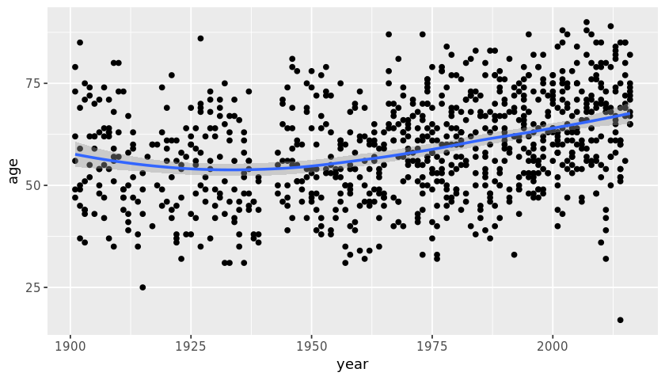

```r
# Loading the lubridate package
library(lubridate)
# Calculating the age of Nobel Prize winners
nobel_age <- nobel %>%
    mutate(age=year-year(as.Date(birth_date)))

# Plotting the age of Nobel Prize winners
nobel_age %>%
    ggplot(aes(year, age))+
    geom_point()+
    geom_smooth()
```

```r
p <- last_plot()

correct_nobel_age <- nobel %>%
    mutate(age = year - year(birth_date))

run_tests({
    test_that("nobel_age$age is correct", {
    expect_true(all(nobel_age$age %in% correct_nobel_age$age),
        info = "nobel_age$age need to have the age of the winner when they received the prize.")
    })

    test_that("correct columns are plotted", {
    mappings <- str_replace(as.character(p$mapping), "~", "")
    expect_true(all(c("year", "age") %in% mappings),
        info = "You should plot year on the x-axis and age on the y-axis.")
    })
})
```

[output not shown]

## 9. Age differences between prize categories

The plot above shows us a lot! We see that people use to be around 55 when they received the price, but nowadays the average is closer to 65. But there is a large spread in the laureates' ages, and while most are 50+, some are very young.

We also see that the density of points is much high nowadays than in the early 1900s -- nowadays many more of the prizes are shared, and so there are many more winners. We also see that there was a disruption in awarded prizes around the Second World War (1939 - 1945).

Let's look at age trends within different prize categories.

```
Warning message:
"Removed 28 rows containing non-finite values (stat_smooth)."Warning message:
"Removed 28 rows containing missing values (geom_point)."
```

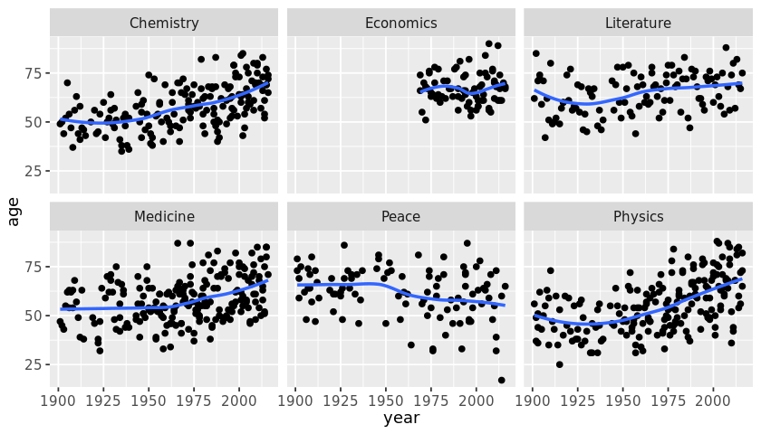

```r
# Same plot as above, but faceted by the category of the Nobel Prize
nobel_age %>%
    ggplot(aes(year, age, group=category))+
    geom_point()+
    geom_smooth(se=FALSE)+
    facet_wrap(~category)
```

```r
facet_class <- class(last_plot()$facet)

run_tests({
    test_that("The plot is faceted", {
    expect_true(! "FacetNull" %in% facet_class,
        info = "The plot needs to be faceted by category. Try using facet_wrap().")
    })
})
```

[output not shown]

## 10. Oldest and youngest winners

Another plot with lots of exciting stuff going on! We see that both winners of the chemistry, medicine, and physics prize have gotten older over time. The trend is strongest for physics: the average age used to be below 50, and now it's almost 70. Literature and economics are more stable, and we also see that economics is a newer category. But peace shows an opposite trend where winners are getting younger!

In the peace category we also a winner around 2010 that seems exceptionally young. This begs the questions, who are the oldest and youngest people ever to have won a Nobel Prize?

```r
nobel_age
```

[output not shown]

```r
# The oldest winner of a Nobel Prize as of 2016
nobel_age %>% top_n(1,age)

# The youngest winner of a Nobel Prize as of 2016
nobel_age %>% top_n(1,desc(age))
```

| year | category | prize | motivation | prize_share | laureate_id | laureate_type | full_name | birth_date | birth_city | birth_country | sex | organization_name | organization_city | organization_country | death_date | death_city | death_country | age |
| --- | --- | --- | --- | --- | --- | --- | --- | --- | --- | --- | --- | --- | --- | --- | --- | --- | --- | --- |
| 2007 | Economics | The Sveriges Riksbank Prize in Economic Sciences 2007 | "for having laid the foundations of mechanism design theory" | 1/3 | 820 | Individual | Leonid Hurwicz | 1917-08-21 | Moscow | Russia | Male | University of Minnesota | Minneapolis, MN | United States of America | 2008-06-24 | Minneapolis, MN | United States of America | 90 |

| year | category | prize | motivation | prize_share | laureate_id | laureate_type | full_name | birth_date | birth_city | birth_country | sex | organization_name | organization_city | organization_country | death_date | death_city | death_country | age |
| --- | --- | --- | --- | --- | --- | --- | --- | --- | --- | --- | --- | --- | --- | --- | --- | --- | --- | --- |
| 2014 | Peace | The Nobel Peace Prize 2014 | "for their struggle against the suppression of children and young people and for the right of all children to education" | 1/2 | 914 | Individual | Malala Yousafzai | 1997-07-12 | Mingora | Pakistan | Female | NA | NA | NA | NA | NA | NA | 17 |

```r
last_value <- .Last.value
correct_last_value <- nobel_age %>% top_n(1, desc(age))

run_tests({
    test_that("The youngest winner is correct", {
    expect_equivalent(last_value$full_name, correct_last_value$full_name,
        info = "The last row you extract in the code cell should be the youngest Nobel Prize winner.")
    })
})
```

[output not shown]

## 11. You get a prize!

[figure not shown]

Hey! You get a prize for making it to the very end of this notebook! It might not be a Nobel Prize, but I made it myself in paint so it should count for something. But don't despair, Leonid Hurwicz was 90 years old when he got his prize, so it might not be too late for you. Who knows.

Before you leave, what was again the name of the youngest winner ever who in 2014 got the prize for "[her] struggle against the suppression of children and young people and for the right of all children to education"?

```r
# The name of the youngest winner of the Nobel Prize as of 2016
youngest_winner <- "Malala Yousafzai"
```

```r
run_tests({
    test_that("youngest_winner is correct", {
    expect_true(any(str_detect(tolower(youngest_winner), c("malala", "yousafzai"))),
        info = "youngest_winner should be a string. Try writing only the first / given name.")
    })
})
```

[output not shown]